# Red Wine Quality Exploration by Kartik Garg

- This data set contains 1,599 red wines with 11 variables on the chemical properties of the wine.
- At least 3 wine experts rated the quality of each wine.
- Rating done on the scale of 0 to 10 where 0 means ‘VERY BAD’ and 10 meand ‘VERY GOOD’.

# Univariate Plots Section

First I am going to explore each individual distribution. This will help me choose the kind of assumptions I can make when applying statistical tests.

Dataset summary (continued below)

| X | fixed.acidity | volatile.acidity | citric.acid |
| --- | --- | --- | --- |
| Min. : 1.0 | Min. : 4.60 | Min. :0.1200 | Min. :0.000 |
| 1st Qu.: 400.5 | 1st Qu.: 7.10 | 1st Qu.:0.3900 | 1st Qu.:0.090 |
| Median : 800.0 | Median : 7.90 | Median :0.5200 | Median :0.260 |
| Mean : 800.0 | Mean : 8.32 | Mean :0.5278 | Mean :0.271 |
| 3rd Qu.:1199.5 | 3rd Qu.: 9.20 | 3rd Qu.:0.6400 | 3rd Qu.:0.420 |
| Max. :1599.0 | Max. :15.90 | Max. :1.5800 | Max. :1.000 |

Table continues below

| residual.sugar | chlorides | free.sulfur.dioxide | total.sulfur.dioxide |
| --- | --- | --- | --- |
| Min. : 0.900 | Min. :0.01200 | Min. : 1.00 | Min. : 6.00 |
| 1st Qu.: 1.900 | 1st Qu.:0.07000 | 1st Qu.: 7.00 | 1st Qu.: 22.00 |
| Median : 2.200 | Median :0.07900 | Median :14.00 | Median : 38.00 |
| Mean : 2.539 | Mean :0.08747 | Mean :15.87 | Mean : 46.47 |
| 3rd Qu.: 2.600 | 3rd Qu.:0.09000 | 3rd Qu.:21.00 | 3rd Qu.: 62.00 |
| Max. :15.500 | Max. :0.61100 | Max. :72.00 | Max. :289.00 |

Table continues below

| density | pH | sulphates | alcohol | quality |
| --- | --- | --- | --- | --- |
| Min. :0.9901 | Min. :2.740 | Min. :0.3300 | Min. : 8.40 | 3: 10 |
| 1st Qu.:0.9956 | 1st Qu.:3.210 | 1st Qu.:0.5500 | 1st Qu.: 9.50 | 4: 53 |
| Median :0.9968 | Median :3.310 | Median :0.6200 | Median :10.20 | 5:681 |
| Mean :0.9967 | Mean :3.311 | Mean :0.6581 | Mean :10.42 | 6:638 |
| 3rd Qu.:0.9978 | 3rd Qu.:3.400 | 3rd Qu.:0.7300 | 3rd Qu.:11.10 | 7:199 |
| Max. :1.0037 | Max. :4.010 | Max. :2.0000 | Max. :14.90 | 8: 18 |

| rating |
| --- |
| bad : 63 |
| average:1319 |
| good : 217 |
| NA |
| NA |
| NA |

### Quality Distribution

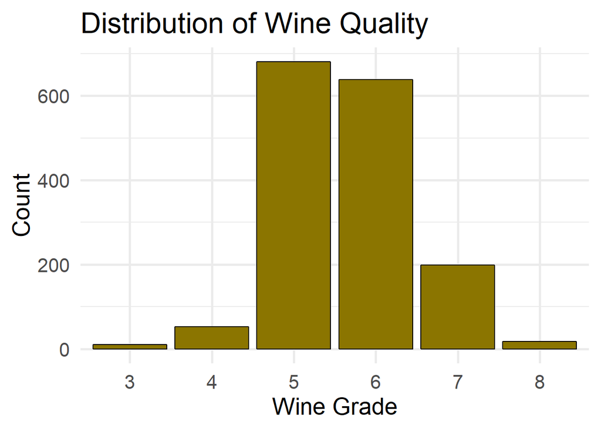

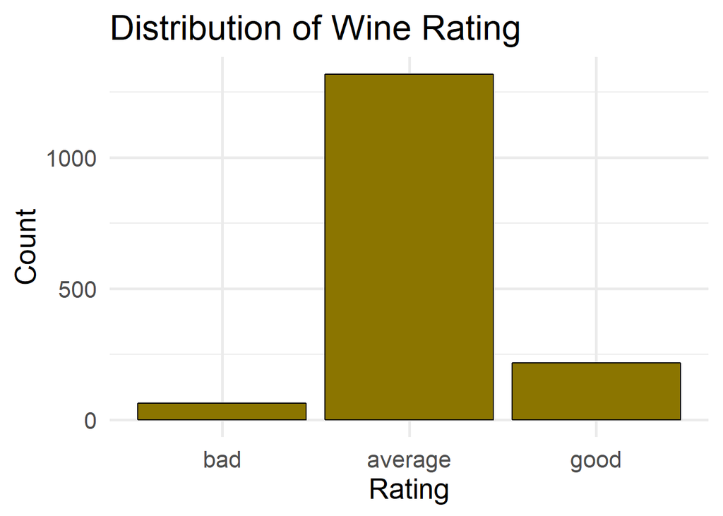

These graphs clearly depict that on a whole the quality of the wine is Average. The high concentration of wines in the center region. The max quality lie between 4 to 7.

### Distribution of Other Chemical Properties

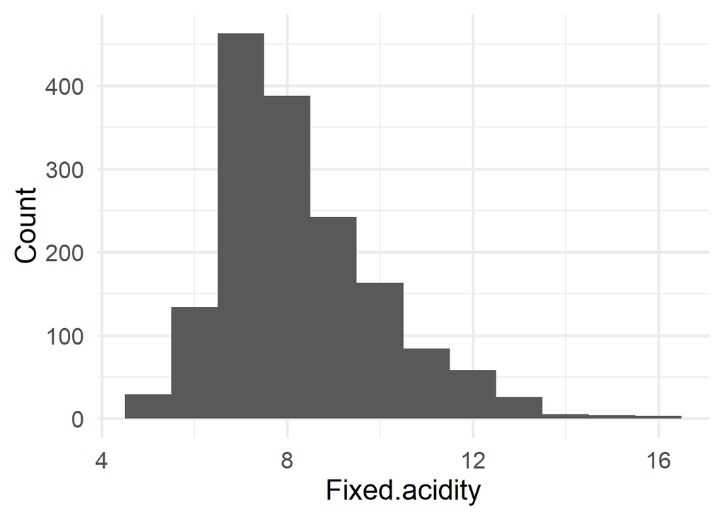

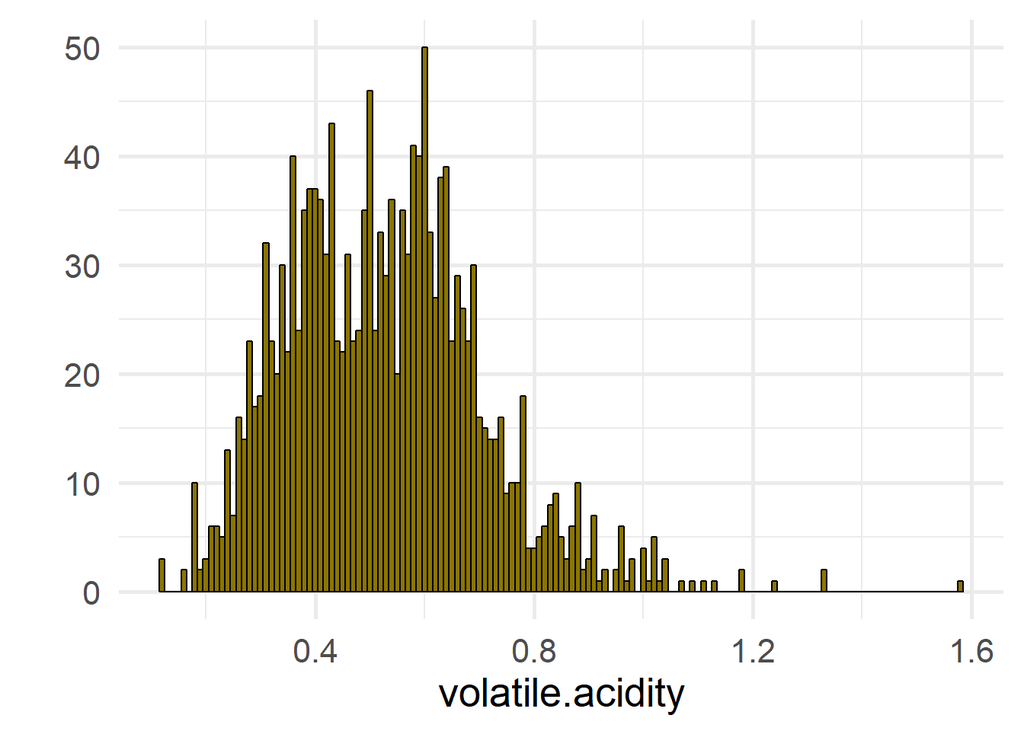

The distribution appears bimodal at 0.4 and 0.6 with some outliers in the higher ranges.

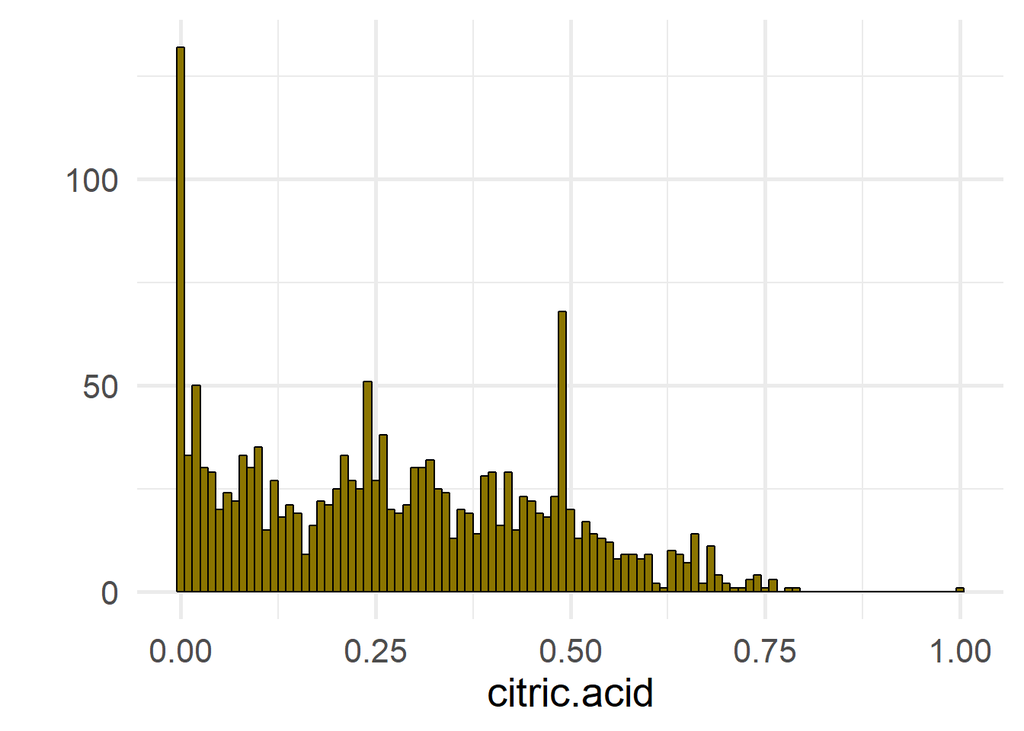

8% of wines do not present critic acid at all. Maybe there is a problem in the data collection process.

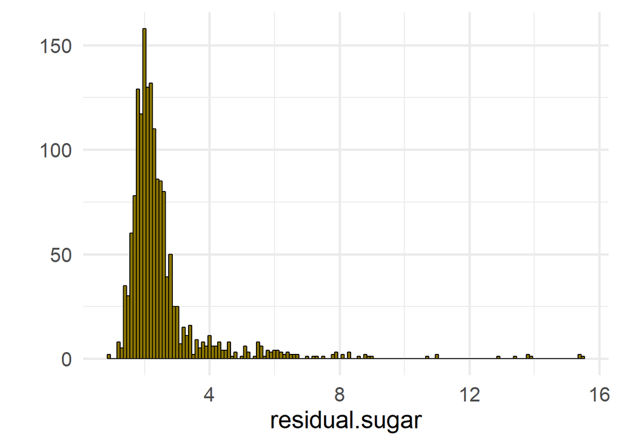

A high concentration of wines around 2.2 (the median) with some outliers along the higher ranges.

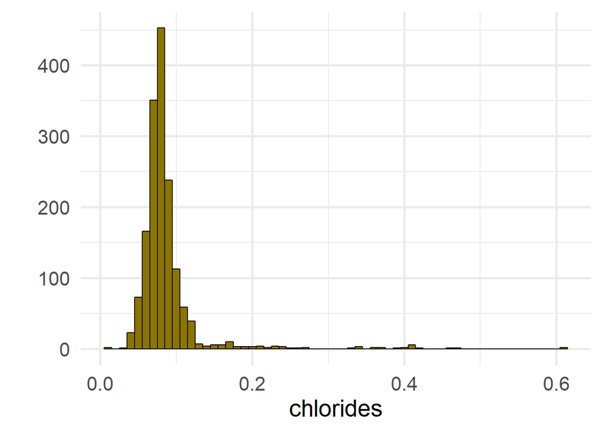

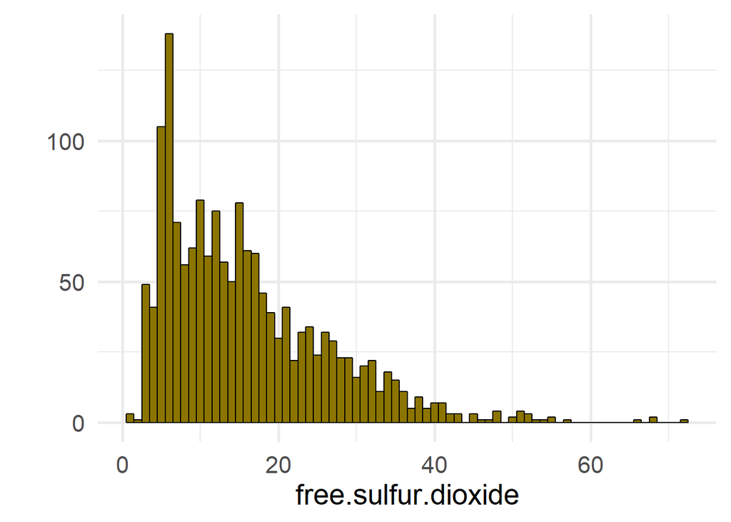

The distributions peaks at around 7 and from then on resembles a long tailed distribution with very few wines over 60.

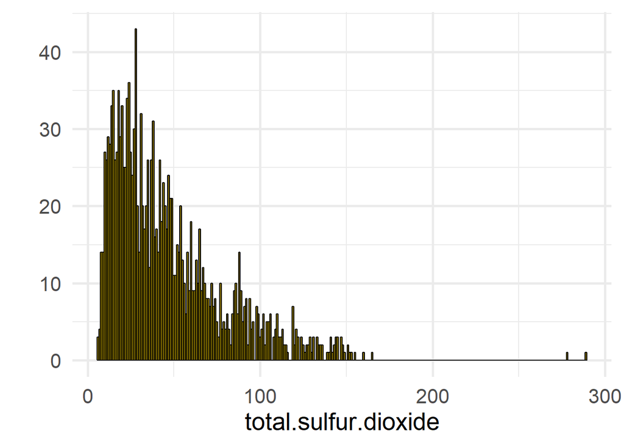

As expected, this distribution resembles closely the last one.

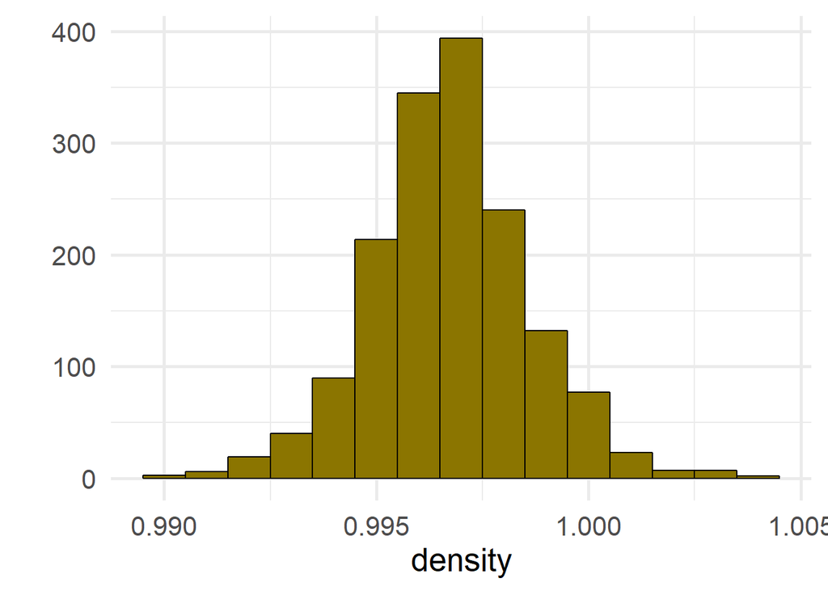

The distribution for density has a very normal appearence.

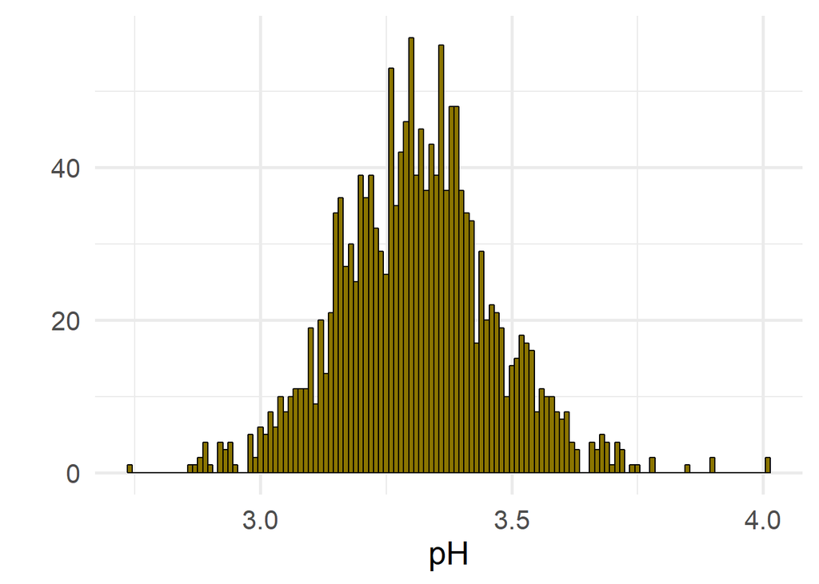

```
## <ScaleContinuousPosition>
##  Range:
##  Limits:    0 --    1
```

pH also looks normally distributed.

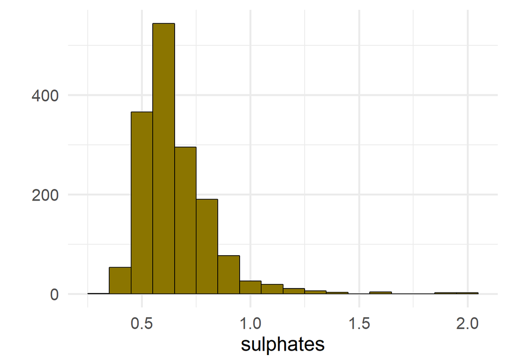

For sulphates we see a distribution similar to the ones of residual.sugar and chlorides.

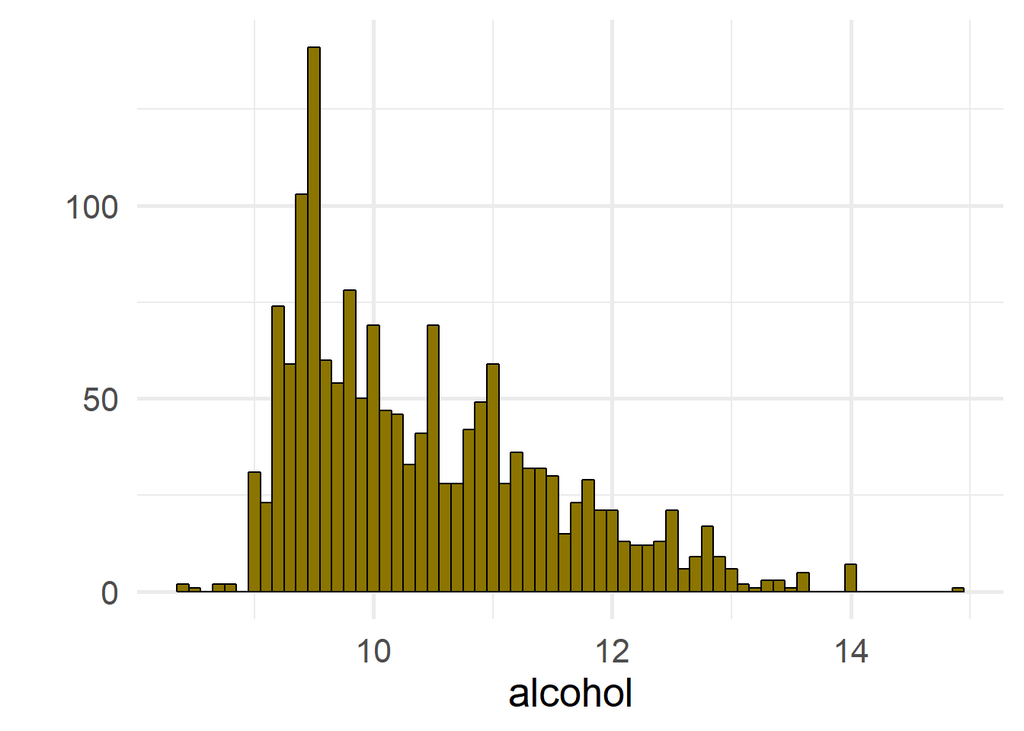

We see the same rapid increase and then long tailed distribution as we saw in sulfur.dioxide. There can be a correlation between the variables.

# Univariate Analysis

### What is the structure of your dataset?

There are 1599 observation of wines in the dataset with 12 features . There is one categorical variable (quality) and the others are numerical variables that indicate wine physical and chemical properties of the wine. In this dataset, most of the wines belong to the ‘average’ quality with very few ‘bad’ and ‘good’ ones.

### What is/are the main feature(s) of interest in your dataset?

The main feature in the dataset is **quality**. I would like to determine which features determine the quality of red wines.

### What other features in the dataset do you think will help support your into your feature(s) of interest?

The variables related to acid concentrations might alter the taste of the wine. Residual.sugar might have an influence in taste and tell how sweet wine is.

### Did you create any new variables from existing variables in the dataset?

Yes,rating variable to improve the later visualizations.

### Of the features you investigated, were there any unusual distributions? you perform any operations on the data to tidy, adjust, or change the form the data? If so, why did you do this?

- In critic acid there were unusual distribtion. 8% of wines do not present critic acid at all.It had rectangularly looking distribution which given the wine quality distribution seems very unexpected. Maybe there is a problem in the data collection process.
- No such operation on data is performed to make it tidy or change its format.

# Bivariate Plots Section

First i will find correlation table between the variables present in the dataset. So that i can find relationships between supporting variable.

Table continues below

|  | fixed.acidity | volatile.acidity | citric.acid |
| --- | --- | --- | --- |
| **fixed.acidity** | 1 | -0.2561 | **0.6717** |
| **volatile.acidity** | -0.2561 | 1 | **-0.5525** |
| **citric.acid** | **0.6717** | **-0.5525** | 1 |
| **residual.sugar** | 0.1148 | 0.001918 | 0.1436 |
| **chlorides** | 0.09371 | 0.0613 | 0.2038 |
| **free.sulfur.dioxide** | -0.1538 | -0.0105 | -0.06098 |
| **total.sulfur.dioxide** | -0.1132 | 0.07647 | 0.03553 |
| **density** | **0.668** | 0.02203 | **0.3649** |
| **pH** | **-0.683** | 0.2349 | **-0.5419** |
| **sulphates** | 0.183 | -0.261 | **0.3128** |
| **alcohol** | -0.06167 | -0.2023 | 0.1099 |
| **quality** | 0.1241 | **-0.3906** | 0.2264 |

Table continues below

|  | residual.sugar | chlorides | free.sulfur.dioxide |
| --- | --- | --- | --- |
| **fixed.acidity** | 0.1148 | 0.09371 | -0.1538 |
| **volatile.acidity** | 0.001918 | 0.0613 | -0.0105 |
| **citric.acid** | 0.1436 | 0.2038 | -0.06098 |
| **residual.sugar** | 1 | 0.05561 | 0.187 |
| **chlorides** | 0.05561 | 1 | 0.005562 |
| **free.sulfur.dioxide** | 0.187 | 0.005562 | 1 |
| **total.sulfur.dioxide** | 0.203 | 0.0474 | **0.6677** |
| **density** | **0.3553** | 0.2006 | -0.02195 |
| **pH** | -0.08565 | -0.265 | 0.07038 |
| **sulphates** | 0.005527 | **0.3713** | 0.05166 |
| **alcohol** | 0.04208 | -0.2211 | -0.06941 |
| **quality** | 0.01373 | -0.1289 | -0.05066 |

Table continues below

|  | total.sulfur.dioxide | density | pH |
| --- | --- | --- | --- |
| **fixed.acidity** | -0.1132 | **0.668** | **-0.683** |
| **volatile.acidity** | 0.07647 | 0.02203 | 0.2349 |
| **citric.acid** | 0.03553 | **0.3649** | **-0.5419** |
| **residual.sugar** | 0.203 | **0.3553** | -0.08565 |
| **chlorides** | 0.0474 | 0.2006 | -0.265 |
| **free.sulfur.dioxide** | **0.6677** | -0.02195 | 0.07038 |
| **total.sulfur.dioxide** | 1 | 0.07127 | -0.06649 |
| **density** | 0.07127 | 1 | **-0.3417** |
| **pH** | -0.06649 | **-0.3417** | 1 |
| **sulphates** | 0.04295 | 0.1485 | -0.1966 |
| **alcohol** | -0.2057 | **-0.4962** | 0.2056 |
| **quality** | -0.1851 | -0.1749 | -0.05773 |

|  | sulphates | alcohol | quality |
| --- | --- | --- | --- |
| **fixed.acidity** | 0.183 | -0.06167 | 0.1241 |
| **volatile.acidity** | -0.261 | -0.2023 | **-0.3906** |
| **citric.acid** | **0.3128** | 0.1099 | 0.2264 |
| **residual.sugar** | 0.005527 | 0.04208 | 0.01373 |
| **chlorides** | **0.3713** | -0.2211 | -0.1289 |
| **free.sulfur.dioxide** | 0.05166 | -0.06941 | -0.05066 |
| **total.sulfur.dioxide** | 0.04295 | -0.2057 | -0.1851 |
| **density** | 0.1485 | **-0.4962** | -0.1749 |
| **pH** | -0.1966 | 0.2056 | -0.05773 |
| **sulphates** | 1 | 0.09359 | 0.2514 |
| **alcohol** | 0.09359 | 1 | **0.4762** |
| **quality** | 0.2514 | **0.4762** | 1 |

### Observation

Volatile acidity has a positive correlation with pH. Density has a very strong correlation with Fixed Acidity. Most strongly correlated variables to quality are Volatile Acidity and Alcohol. Alcohol has negative correlation with density.

### Quality Vs Other variables box plot :

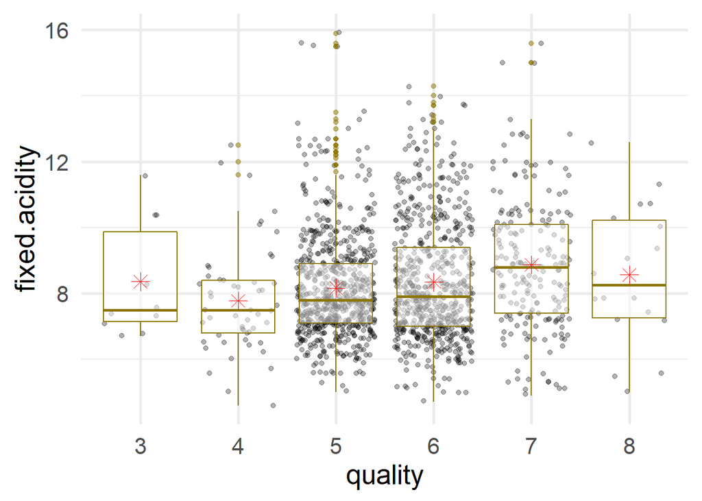

The mean and median values of fixed acidity remains almost unchanged with increase in quality.

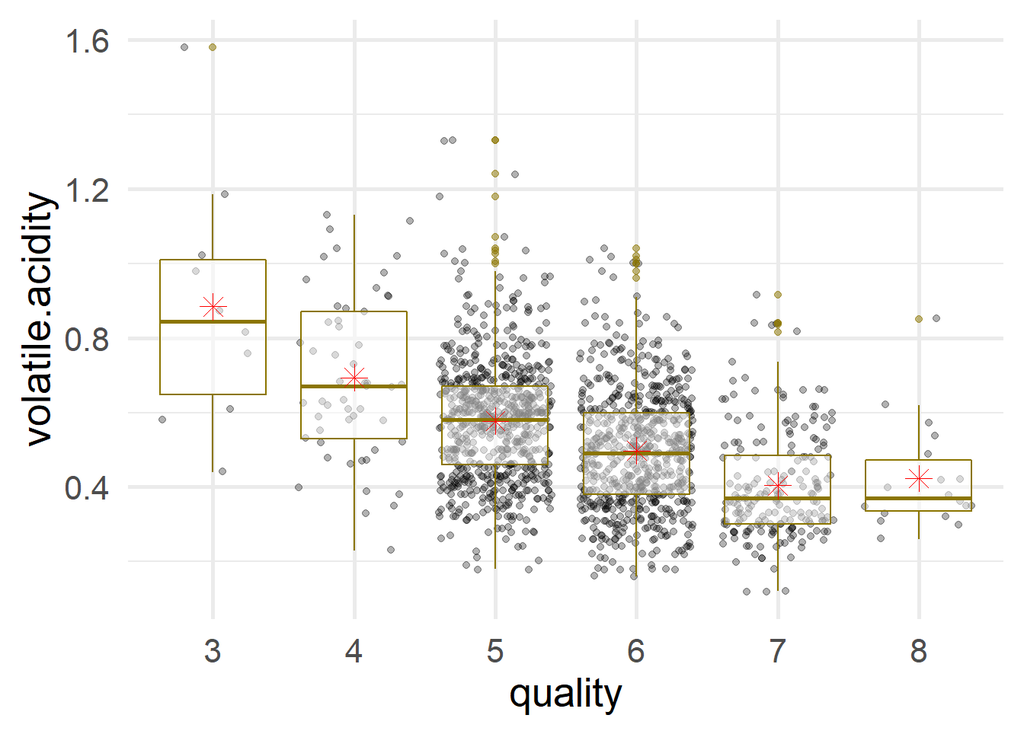

As volatile acid level goes up, the quality of the wine degrades.

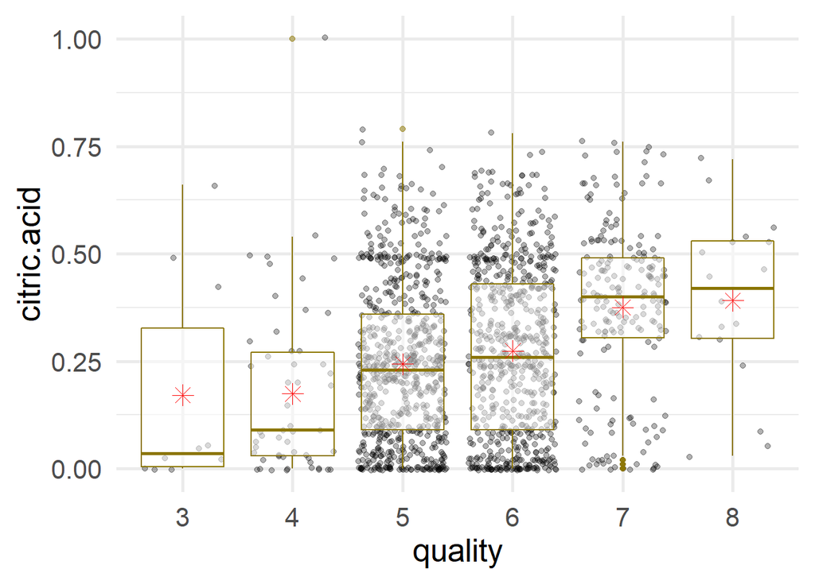

More the Citric Acid Better the wines will be.

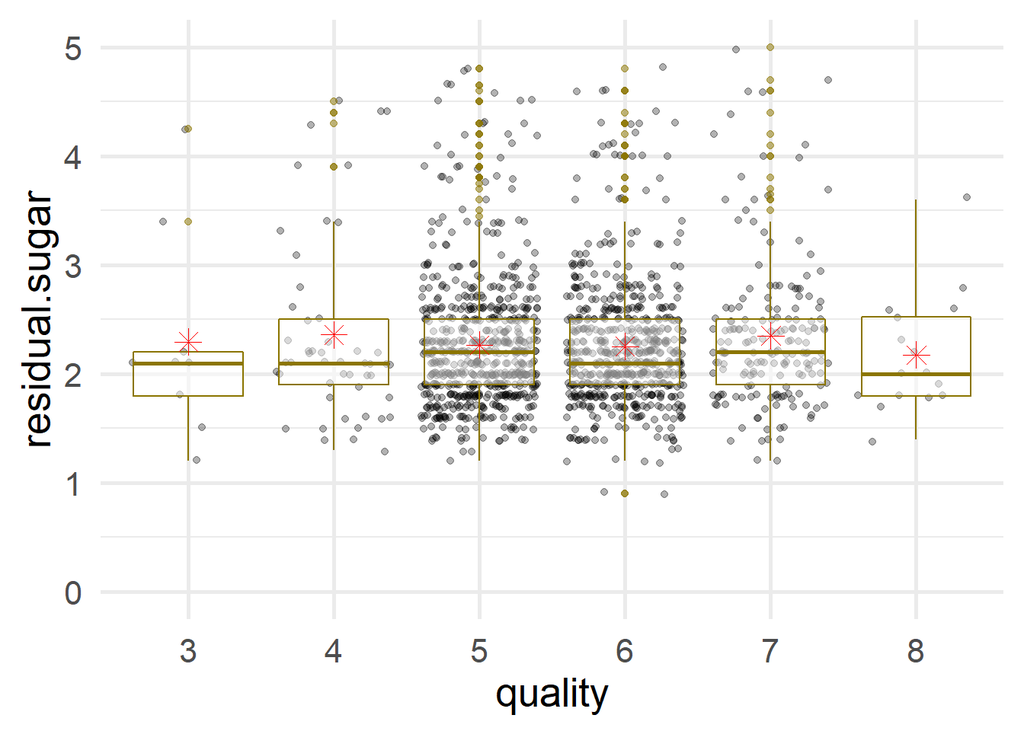

The mean values for the residual sugar is almost the same for every quality of wine.

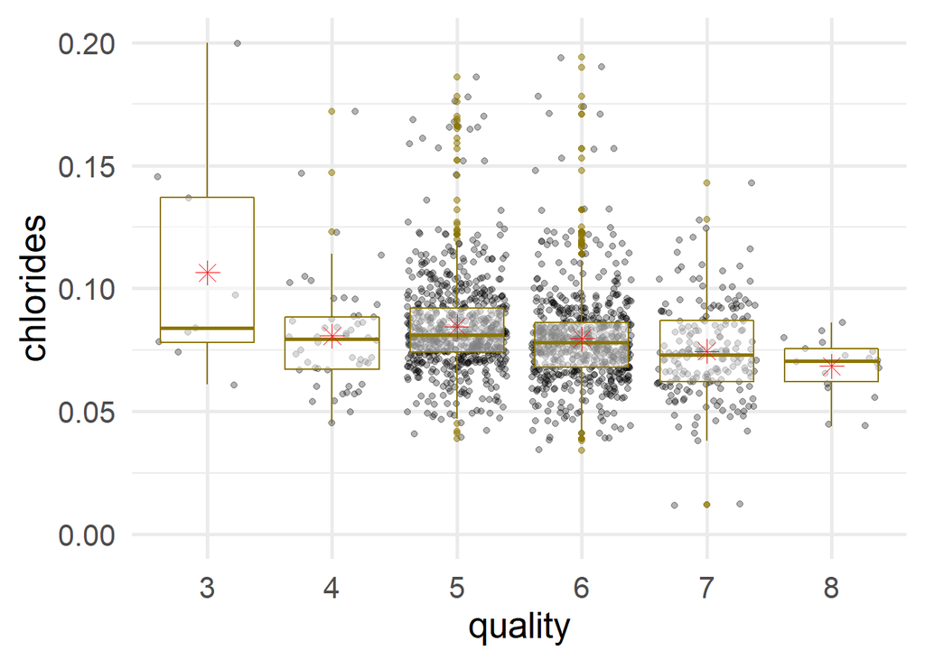

Weakly correlated, lower percent of Chloride seems to produce better wines.

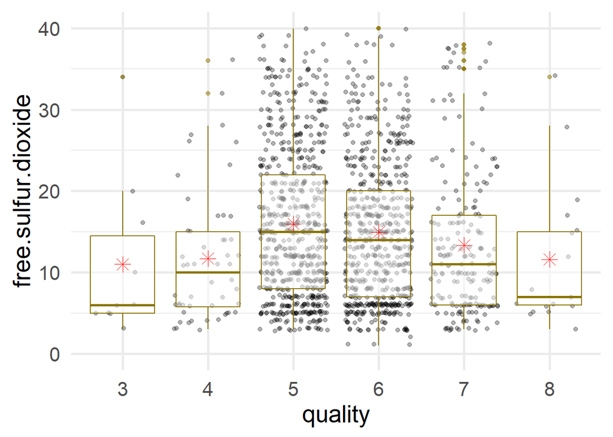

Too low concentration of Free Sulphur Dioxide produces poor wine and too high concentration results in average wine.

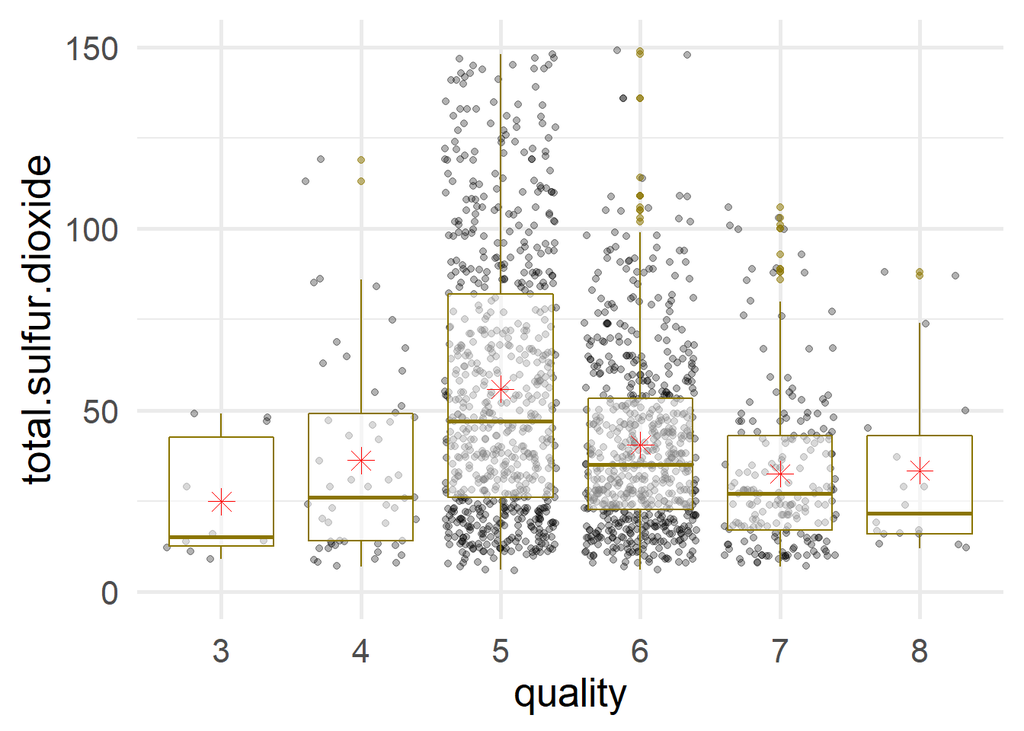

Observation same as Free Sulphur Dioxide.

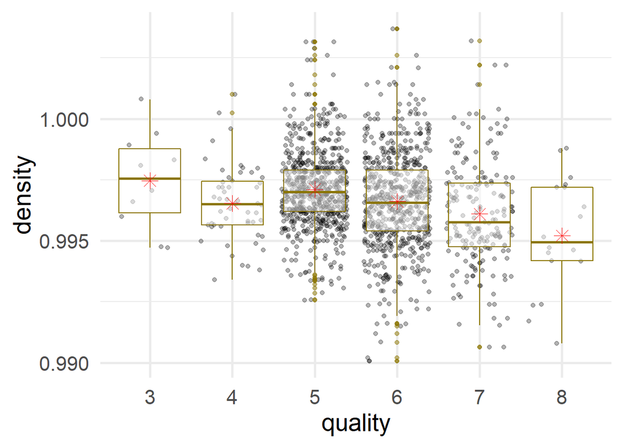

Better wines seems to have lower densities. But higher alcohol content which actually is the driving factor can be a reason for better wines.

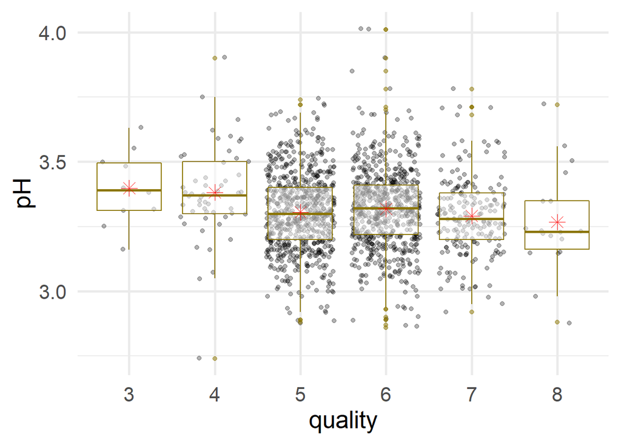

Better wines seems to have less pH, i.e they are more acidic.There are a quite a few outliers here.

#### logarithm function tends to squeeze together the larger values in your data set and stretches out the smaller values. To prevent outliers i will be using **log 10**.

*Individual acids vs pH graph:*

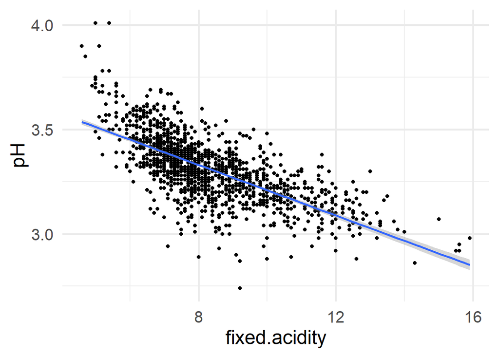

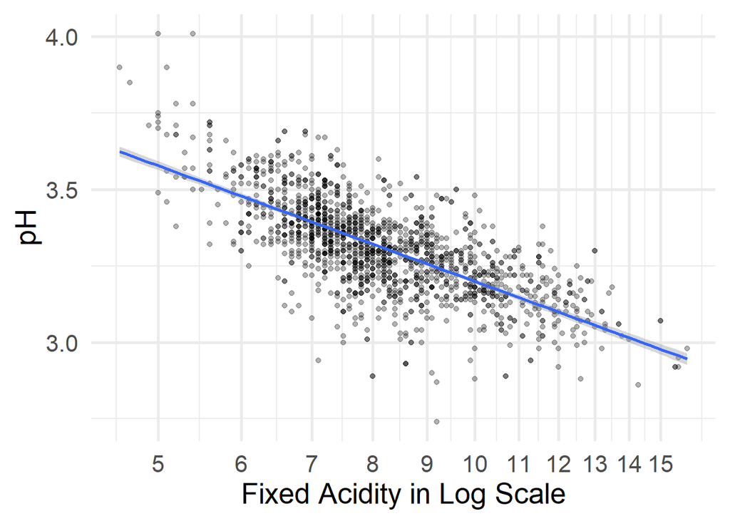

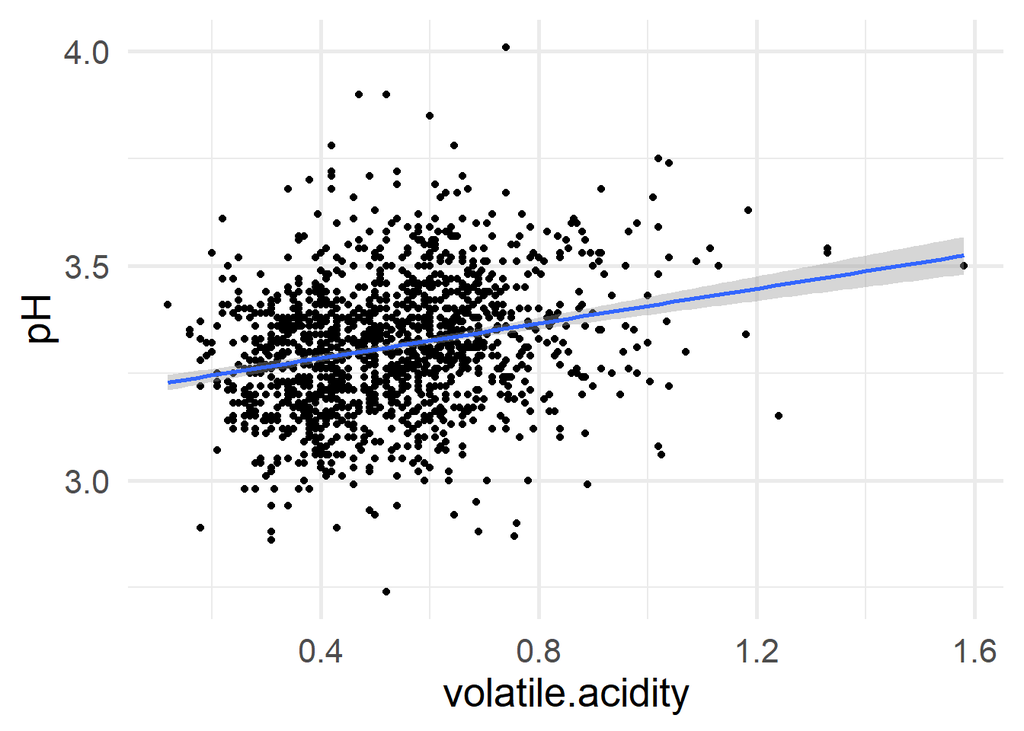

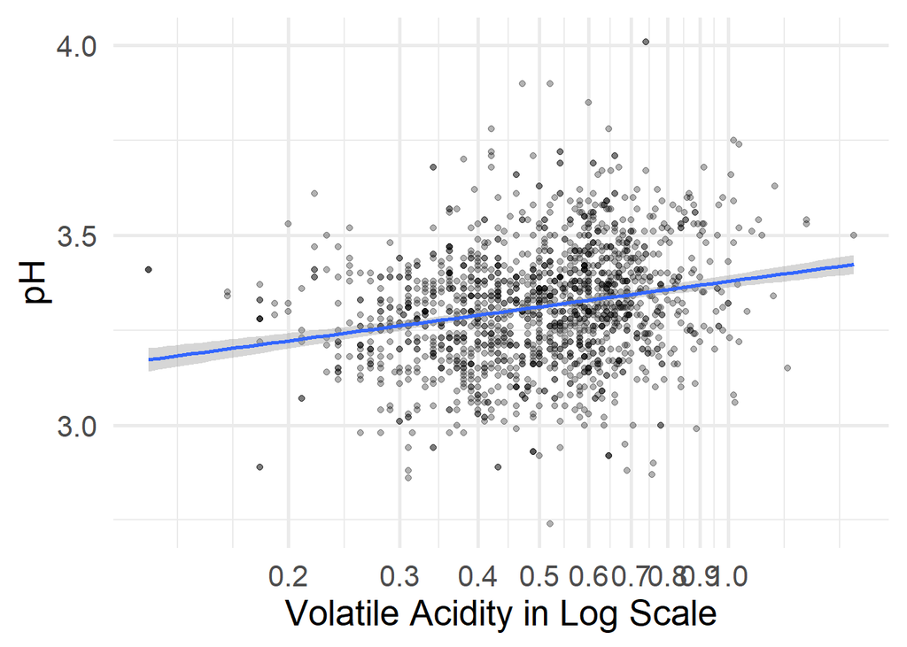

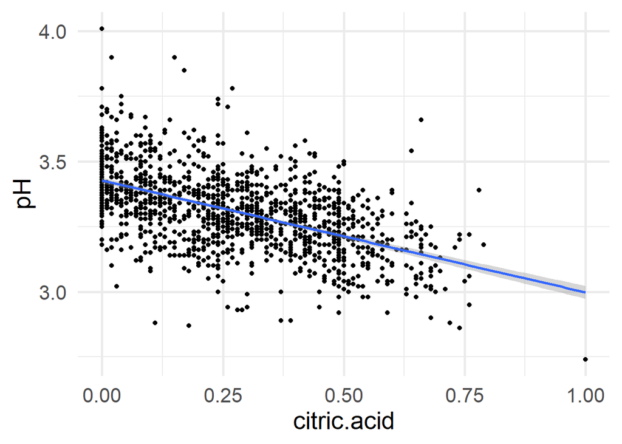

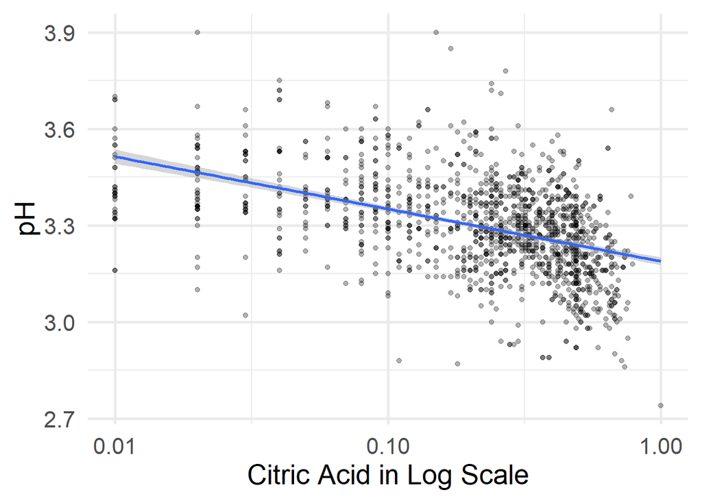

For Volatile Acid, pH has a positive correlation. But acidity has a negative correlation with pH.

*To check weither simpsons paradox play a role or not:*

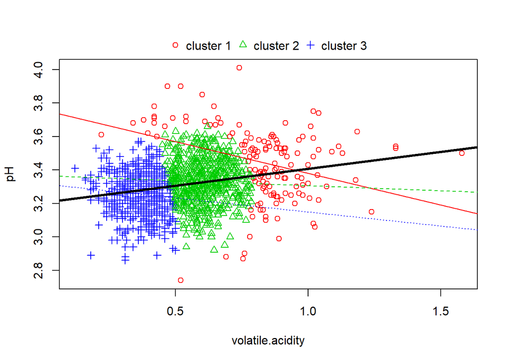

- As per the observation it is **Simpsons paradox** which was responsible for the trend reversal of Volatile Acid vs pH.
- 3 clusters are made later regression coefficient is calculated.
- There is indeed a sign reversal.
- This is due to a lurking variable which changes the overall coefficient.

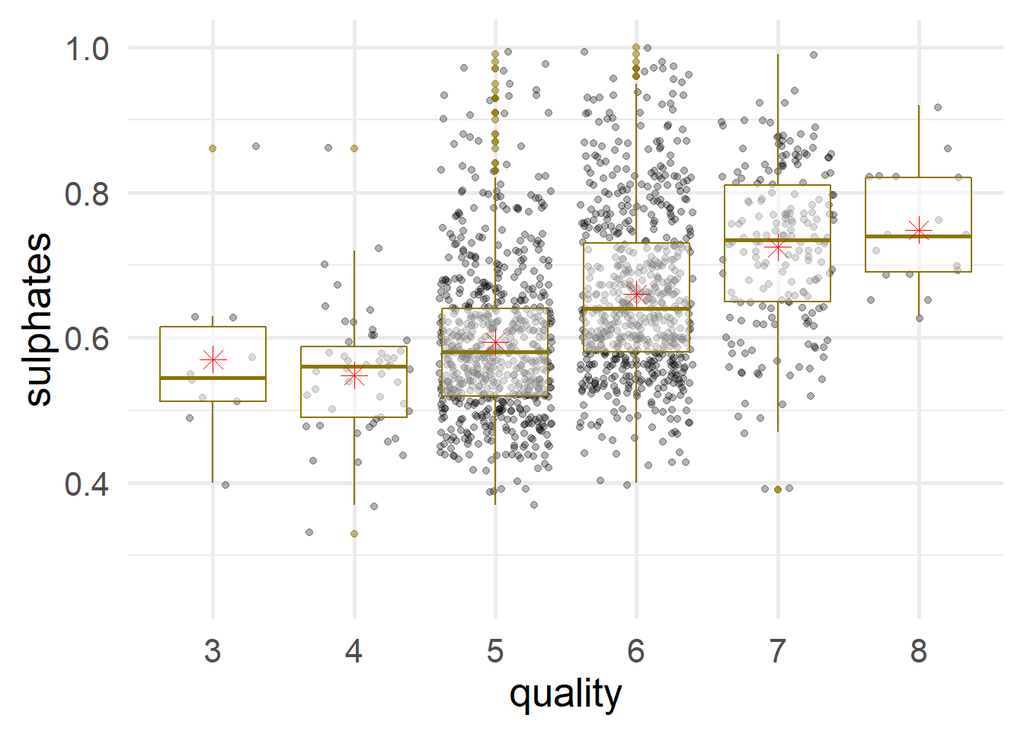

It seems that better wines have a stronger concentration of Sulphates. Max outliers present in the average zone.

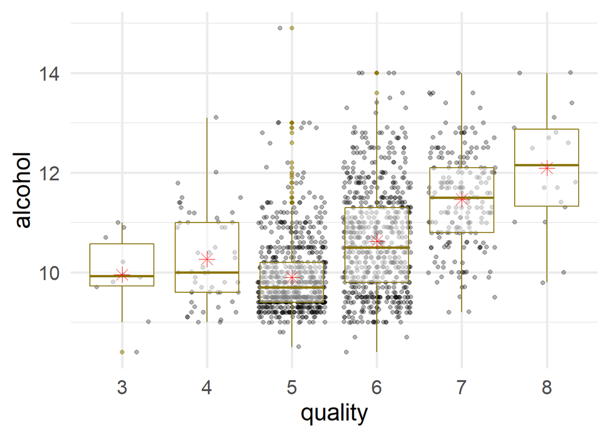

Better wines have higher Alcohol content in it. But due to great number of outliers it might be possible that alcohol alone does not contribute to a wine being a good quality one.

```
##
## Call:
## lm(formula = as.numeric(quality) ~ alcohol, data = redwine)
##
## Residuals:
##     Min      1Q  Median      3Q     Max
## -2.8442 -0.4112 -0.1690  0.5166  2.5888
##
## Coefficients:
##             Estimate Std. Error t value Pr(>|t|)
## (Intercept) -0.12503    0.17471  -0.716    0.474
## alcohol      0.36084    0.01668  21.639   <2e-16 ***
## ---
## Signif. codes:  0 '***' 0.001 '**' 0.01 '*' 0.05 '.' 0.1 ' ' 1
##
## Residual standard error: 0.7104 on 1597 degrees of freedom
## Multiple R-squared:  0.2267, Adjusted R-squared:  0.2263
## F-statistic: 468.3 on 1 and 1597 DF,  p-value: < 2.2e-16
```

Based on the value of R squared, we see that Alcohol alone contributes to only about 22% of the Wine quality. So there must be other variables at play here. I have to figure them out in order to build a better regression model.

1. Alcohol
2. Sulphates(log10)
3. Volatile Acidity
4. Citric Acid

# Bivariate Analysis

### Talk about some of the relationships you observed in this part of the . How did the feature(s) of interest vary with other features in dataset?

Fixed.acidity seems to have little to no effect on quality. Volatile.acidity goes down quality go up. The higher ranges seem to produce more average and poor wines. Better wines tend to have higher concentration of citric acid,higher concentration of sulphates, lower concentration of chlorides, lower densities. In terms of pH more the acid is better will be wines. Alcohol has a strong correlation with quality but not alone other variable also play a good role.

### Did you observe any interesting relationships between the other features (not the main feature(s) of interest)?

Volatile acidity had a positive correlation with pH which was due to the Simpsons Paradox. Strong relation was found between free and total sulfur.dioxide.